# Loan Data from Prosper : Communicate findings

## by Parvin Mammadov

## Investigation Overview

In this investigation, the purpose is to check the characteristics of loans that could be used to predict interactions among features. The central concentration was on the original loan amount, borrower rate, employmet status, loan term, borrower's stated monthly income.

## Dataset Overview

The dataset contains 113,937 loans with 81 features.I expect that the 13 features that I select in df will help to support the investigation. The attributes included original loan amount, borrower's Prosper rating, loan term, borrower's stated monthly income, as well as many other features such as borrower's employment status, loan status etc.

## Checking of Loan Status

The biggest part of the loans are current loans,past due loans are divided several groups based on the lenght of payment delay. Accordingly the second biggest group is completed loans and chargedoff compromise significant proportion and defaulted loans look very rare.

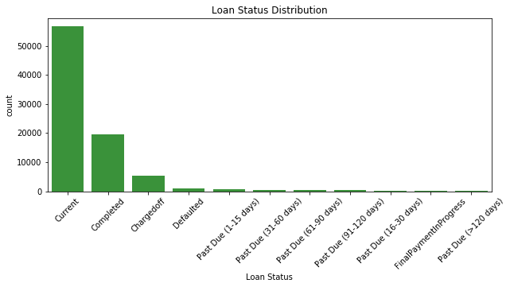

## Distribution of Original Loan Amount

Amount that borrowed many times are 4500 , 10000 , 15000.

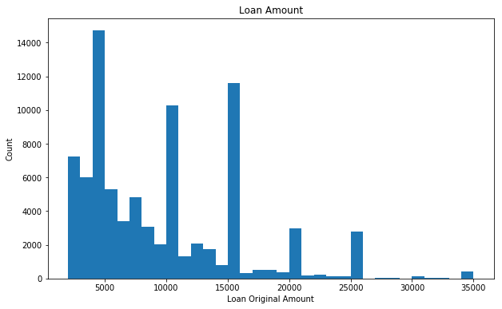

## Loan Origination Year vs Loan Original Amount

As it shown in the aerly years the borrowed amount was less , the regplot shows that the loan amount is inclined to increase year by year.

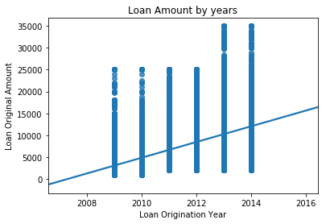

## Employment Status vs Borrower Rate

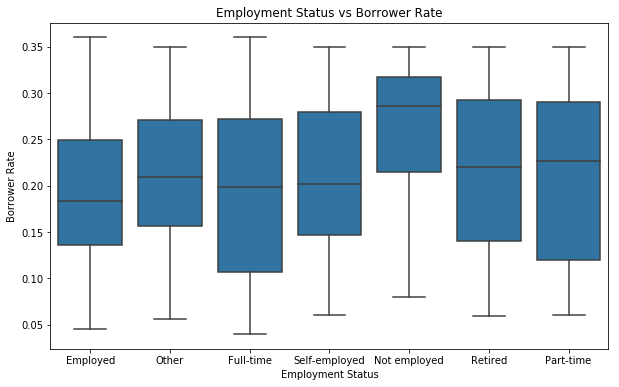

## Prosper Rating (Alpha) and BorrowerAPR vs Term

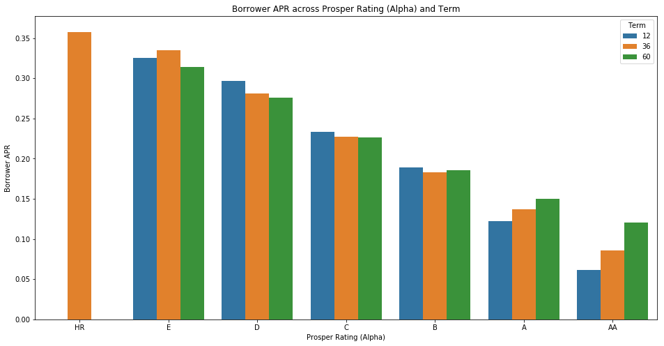